# OBH paper draft

Elements Wilderness Program Research Team

9/19/2021

# Potential Predictors of OBH Client Success

Analysis of adolescents attending Outdoor Behavioral Healthcare (OBH) programs which are part of the National Association of Therapeutic Schools and Programs Practice Research Network (NATSAP PRN) in the United States. For more information visit natsap.org and obhcouncil.com.

The following is detailed explanation of a working paper to be submitted for peer review to the journal of Residential Treatment for Children & Youth.

## Objective

To determine if there are any significant predictors of adolescent client success in OBH treatment. All clients were given the Youth Outcome Questionnaire (YOQ) at both intake and discharge, a peer reviewed measurement frequently used to assess mental health functioning in adolescents. Finding the change between the intake and discharge scores can be used to determine if the client met the Reliable Change Index (RCI). Previous studies have found that meeting the RCI corresponds to a clinically significant change in the individual, i.e. a behavioral and mood change that is apparent both to the individual and those in contact with the individual.

“Success” in this paper is defined as a client meeting the Reliable Change Index (RCI) when their intake and discharge scores were compared.

```r
# Removes all code from the output

library(tidyverse)
library(janitor) # For tabyl
library(knitr) # for kable
library(psych)
knitr::opts_chunk$set(echo = FALSE)


getwd()
```

```
## [1] "C:/Users/cullo/OneDrive/Desktop/One Cloud/Resume 2022/Github Portfolio/OBH_Predictors"
```

```r
# Load OBH NATSAP dataset and name "obh"
obh_org <- readRDS("C:/Users/cullo/OneDrive/Desktop/One Cloud/ELEMENTS/OBH_CF_CC/rds/obh_for_logistic.rds")
```

**To view the cleaning script for this file, please visit “OBH cleaning.R” on Github**

## Predictor Variable Selection

Predictor variables used in this study were selected based on presence in other OBH studies.

- gender
- adopted
- attention_issue
- autism
- conduct_disorder
- depression
- substance_abuse
- trauma_related_issue
- program_need
- change_desire
- prior_prog
- progress_need
- Routine Monitoring Status
- transport
- Rel01 intake difference z score

## YOQ Scores

Clients were given the Y-OQ survey at intake and discharge. An individual’s change score was calculated by subtracting their intake score from their discharge score. Only individuals with self-report Y-OQ scores at admission and discharge were included.

Table : Client YOQ Scores

|  | n | mean | sd | min | max | range | se |
| --- | --- | --- | --- | --- | --- | --- | --- |
| intake | 2470 | 71.09 | 33.43 | -16 | 189 | 205 | 0.67 |
| discharge | 2470 | 48.54 | 32.02 | -16 | 168 | 184 | 0.64 |
| change_score | 2470 | -22.55 | 35.48 | -153 | 102 | 255 | 0.71 |

## Reliable Change Index

The Reliable Change Index (RCI) is the criteria used to evaluate if a clinically significant change of behavioral and mental health improvement has occurred between initial intake and completion of an OBH program. The RCI for the YOQ Youth Self Report is a change of 18 points while the RCI for the YOQ Parent Report is a change of 13. The RCI provides a statistical measure to determine clinical change.

Table : Reliable Change Index

| rci | n | perc |
| --- | --- | --- |
| 0 | 1122 | 45.43 |
| 1 | 1348 | 54.57 |

Participants in this study had consented to being part of the NATSAP PRN and had attended an Outdoor Behavioral Healthcare program between 2018 and 2021. The mean age of the sample was 15.40 (SD = 1.32 years). Participants included individuals with a variety of presenting problems including attention issues, Autism Spectrum Disorder, anxiety, Conduct Disorder, depression and substance abuse (see Table 1).

Table 1: Participant Demographics

| variable | response | n | percent |
| --- | --- | --- | --- |
| gender | FEMALE | 881 | 35.67 |
| gender | MALE | 1537 | 62.23 |
| gender | NA | 52 | 2.11 |
| adopted | 0 | 2088 | 84.53 |
| adopted | 1 | 382 | 15.47 |
| attention_issue | 0 | 2082 | 84.29 |
| attention_issue | 1 | 388 | 15.71 |
| autism | 0 | 2282 | 92.39 |
| autism | 1 | 188 | 7.61 |
| anxiety | 0 | 1610 | 65.18 |
| anxiety | 1 | 860 | 34.82 |
| conduct_disorder | 0 | 2151 | 87.09 |
| conduct_disorder | 1 | 319 | 12.91 |
| depression | 0 | 1491 | 60.36 |
| depression | 1 | 979 | 39.64 |
| substance_abuse | 0 | 1888 | 76.44 |
| substance_abuse | 1 | 582 | 23.56 |
| trauma_related_issue | 0 | 2159 | 87.41 |
| trauma_related_issue | 1 | 311 | 12.59 |
| rom | 0 | 2204 | 89.23 |
| rom | 1 | 266 | 10.77 |
| transport | No | 1039 | 42.06 |
| transport | Yes | 1173 | 47.49 |
| transport | NA | 258 | 10.45 |

In addition to collecting this demographic data, participants were asked to respond to four self report variables. These were presented on a likert scale from 0 (least/strongly disagree) to 10 (most/strongly agree). The following four statements from the NATSAP AQI were included in the analysis:  
* **program_need** = “It makes sense for me to be in this therapeutic program.”  
* **change_desire** = “I would like to make a positive change in my life.”  
* **prior_progress** = “Prior to coming to this program, how much therapeutic progress do you believe you have made by previously engaging in therapy?”  
* **progress_need** = “How much therapeutic progress do you believe you need to make at this current program?”

```
## # A tibble: 8 x 2
##   Variable           value
##   <chr>              <dbl>
## 1 program_need_mean   4.81
## 2 program_need_sd     3.32
## 3 change_desire_mean  7.93
## 4 change_desire_sd    2.56
## 5 prior_prog_mean     5.08
## 6 prior_prog_sd       3.03
## 7 progress_need_mean  5.62
## 8 progress_need_sd    3.39
```

## New Variable Creation

Clinicians have long wondered if the difference in intake scores between parents and their children lead to differences in program success for the adolescent. We attempt to answer this question by creating a new variable to measure the intake difference, **intake_dif**. Shown in Figure 1 is the *Intake distribution difference* between parents and clients.

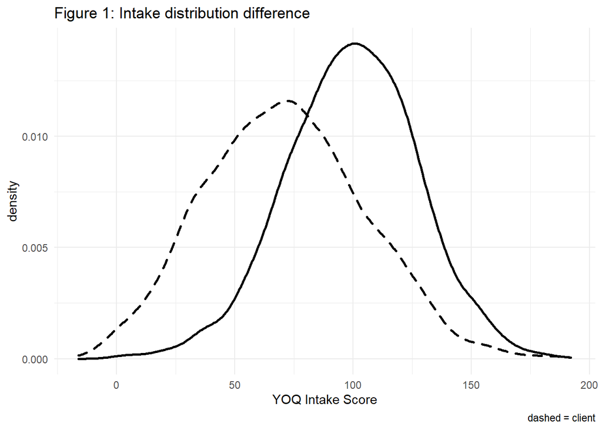

Both client and parent scores at intake were converted into z-scores to ensure like comparisons. Figure 2 illustrates these z-score distributions.

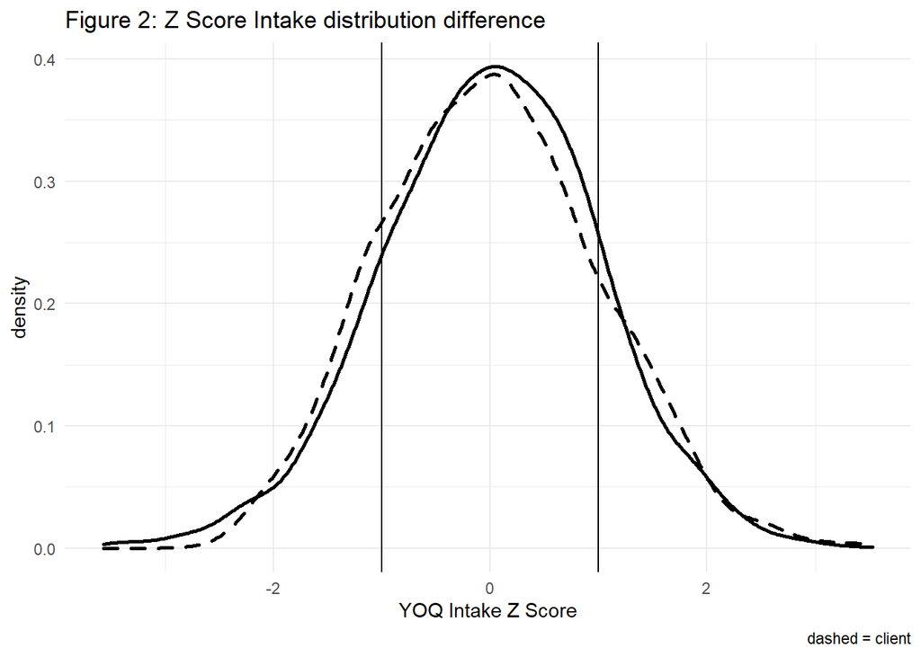

Next, we subtracted the client intake z-scores from the parent intake z-scores to produce the intake difference z-score (Figure 3). For further ease of understanding the data, the raw z-scores were broken out into three groups based on standard deviation distribution: similar scorers, high scoring clients, and high scoring parents. Note, some values are missing as some cases are missing parent intake scores. These are recorded as *NA*.

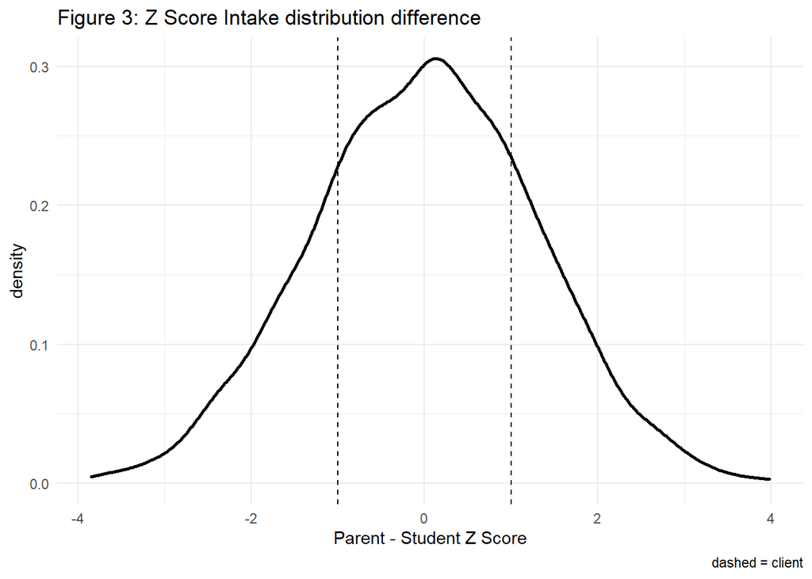

## Logistic Regression

```
##
## Call:
## glm(formula = rci ~ ., family = "binomial", data = obh_log)
##
## Deviance Residuals:
##     Min       1Q   Median       3Q      Max
## -2.2801  -1.0678   0.5718   1.0133   1.9596
##
## Coefficients:
##                      Estimate Std. Error z value Pr(>|z|)
## (Intercept)          -1.96705    0.72511  -2.713 0.006672 **
## genderMALE           -0.43430    0.11488  -3.780 0.000157 ***
## age_intake            0.13031    0.04491   2.901 0.003714 **
## adopted1             -0.24634    0.13842  -1.780 0.075131 .
## attention_issue1     -0.07786    0.15119  -0.515 0.606546
## autism1              -0.15270    0.19748  -0.773 0.439381
## anxiety1             -0.02690    0.11763  -0.229 0.819145
## conduct_disorder1     0.05609    0.15534   0.361 0.718025
## depression1           0.39230    0.11251   3.487 0.000489 ***
## substance_abuse1      0.02179    0.12816   0.170 0.865003
## trauma_related_issue -0.15972    0.16460  -0.970 0.331857
## rom                   0.69344    0.17301   4.008 6.12e-05 ***
## program_need          0.03208    0.02093   1.532 0.125427
## change_desire         0.01878    0.02318   0.810 0.417863
## prior_prog           -0.04699    0.01733  -2.711 0.006699 **
## progress_need         0.04091    0.02017   2.029 0.042477 *
## transportYes         -0.06132    0.10980  -0.558 0.576533
## z_dif_levelsparH     -0.82349    0.13271  -6.205 5.47e-10 ***
## z_dif_levelsstuH      0.89692    0.14199   6.317 2.67e-10 ***
## ---
## Signif. codes:  0 '***' 0.001 '**' 0.01 '*' 0.05 '.' 0.1 ' ' 1
##
## (Dispersion parameter for binomial family taken to be 1)
##
##     Null deviance: 2436.3  on 1766  degrees of freedom
## Residual deviance: 2172.7  on 1748  degrees of freedom
## AIC: 2210.7
##
## Number of Fisher Scoring iterations: 4
```

|  | Estimate | Std. Error | z value | Pr(>\|z\|) | oddrat |
| --- | --- | --- | --- | --- | --- |
| (Intercept) | -1.967 | 0.725 | -2.713 | 0.007 | 0.140 |
| genderMALE | -0.434 | 0.115 | -3.780 | 0.000 | 0.648 |
| age_intake | 0.130 | 0.045 | 2.901 | 0.004 | 1.139 |
| adopted1 | -0.246 | 0.138 | -1.780 | 0.075 | 0.782 |
| attention_issue1 | -0.078 | 0.151 | -0.515 | 0.607 | 0.925 |
| autism1 | -0.153 | 0.197 | -0.773 | 0.439 | 0.858 |
| anxiety1 | -0.027 | 0.118 | -0.229 | 0.819 | 0.973 |
| conduct_disorder1 | 0.056 | 0.155 | 0.361 | 0.718 | 1.058 |
| depression1 | 0.392 | 0.113 | 3.487 | 0.000 | 1.480 |
| substance_abuse1 | 0.022 | 0.128 | 0.170 | 0.865 | 1.022 |
| trauma_related_issue | -0.160 | 0.165 | -0.970 | 0.332 | 0.852 |
| rom | 0.693 | 0.173 | 4.008 | 0.000 | 2.001 |
| program_need | 0.032 | 0.021 | 1.532 | 0.125 | 1.033 |
| change_desire | 0.019 | 0.023 | 0.810 | 0.418 | 1.019 |
| prior_prog | -0.047 | 0.017 | -2.711 | 0.007 | 0.954 |
| progress_need | 0.041 | 0.020 | 2.029 | 0.042 | 1.042 |
| transportYes | -0.061 | 0.110 | -0.558 | 0.577 | 0.941 |
| z_dif_levelsparH | -0.823 | 0.133 | -6.205 | 0.000 | 0.439 |
| z_dif_levelsstuH | 0.897 | 0.142 | 6.317 | 0.000 | 2.452 |

## Follow up Test

A possible confounding factor to interpreting the intake difference variable as being significant to the model is if adolescents who scored higher than their parents are simply adolescents who also scored higher than the general sample at intake and that those with higher scores at intake are more likely to meet the RCI at discharge.

```
##
##  Pearson's Chi-squared test with Yates' continuity correction
##
## data:  stu_high$rci and stu_high$z_dif_levels
## X-squared = 8.4375, df = 1, p-value = 0.003676
```

There was a significant relationship between the two variables (X2 = 8.44, df = 1, p = .004). This supports the finding from the logistic regression model that adolescents who scored one or more standard deviations higher than their parents were more likely to meet the RCI than adolescents who scored similarly to parents at intake.

## Conclusion

Overall, 54.57% of the individuals in this study experienced successful treatment gains, defined as meeting the RCI, and 45.43% did not. Several variables proved to be meaningful predictors of clinically significant change from the logistic regression model. Meaningful predictor variables are listed below in order of decreasing odds ratio:

- High Scoring Student - 2.45 *(compared to students who scored similar to parents)*
- Routine Outcome Monitoring - 2.00
- Depression - 1.48
- Age at intake - 1.14
- Progress Need - 1.04
- Prior Progress - .95
- Gender Male - .65 *(.65 compared to when gender is female)*
- High Scoring Parents - .44 *(compared to students who scored similar to parents)*

  The presence of routine outcome monitoring resulted in a case being two times as likely to meet the RCI at discharge. Although the information is not available in the data set, this outcome could be due in part to programs who collect this data from clients utilizing it to make therapeutically informed decisions based on their client’s progress trajectory (Lambert & Harmon, 2018). This finding could also be due to the fact that merely having clients fill out the YOQ survey of mental health functioning could result in beneficial treatment gains due to something like the Hawthorne effect, where subjects modify some aspect of their behavior in response to being observed (Allen & Davis, 2011).

  Male participants were 35% less likely to to meet the RCI upon discharge from an OBH program. This finding is fairly consistent in the OBH and general mental health treatment research (Tucker et al., 2014, Combs et al., 2016) and may be due to female clients rating their level of psychological distress to be higher than males at intake (DeMille et al., 2018, Combs et al., 2016, Tucker, Pau et al., 2016). Females were also found to make psychological improvements faster than males, which could result in larger RCI differences (Combs et al., 2016). Older adolescents were more likely to meet the RCI, for each year increase in a participant, the likelihood of them meeting the RCI increased by 13%, which is consistent with some research (Bowen & Neill, 2013). One possible explanation is that older individuals, due to a more mature outlook on the world, are more invested in their therapeutic experience. This data also supports the existing literature which asserts the benefits of OBH programs for adolescents experiencing depression could greatly benefit from OBH treatment. Individuals with depression were about 1.48 times more likely than those individuals not diagnosed with depression to meet the RCI. This finding may be understood in terms of how many aspects inherent to OBH have also been shown to be helpful to depression as well: social interaction, purpose, exercise, exposure to nature (Blake, 2012; Mygind, et al., 2019 , are these citations necessary or common knowledge?) among others.

  The new variable defined in this study, the difference between parent and client scores at intake, was also shown to be a significant predictor in the model. Adolescents who scored one or more standard deviation lower than their parents at intake were less than half as likely to meet the RCI than those who had scored within one standard deviation. Alternatively, adolescents who scored one or more standard deviations above their parents were 2.45 times more likely to meet the RCI than those who had scored within one standard deviation of parents. When controlling for high scoring adolescents, the difference in likelihood of meeting the RCI remained between adolescents who scored higher than parents and those who scored similarly. One possible explanation could be that high levels of disagreement between parents and adolescents have an impact on if an adolescent meets the RCI. Specifically, if adolescents judge their issues to be much less acute than their parents do, they may have a harder time seeing the reality of their situation and thus be less likely to engage in therapy. Further, if adolescents judge their issues to be more extreme than their parents, they may be more likely to work harder while in the program.